# HSC Survey Results

# Scots Bay Survey # 5 Results from 30/06/2025

## Survey Details

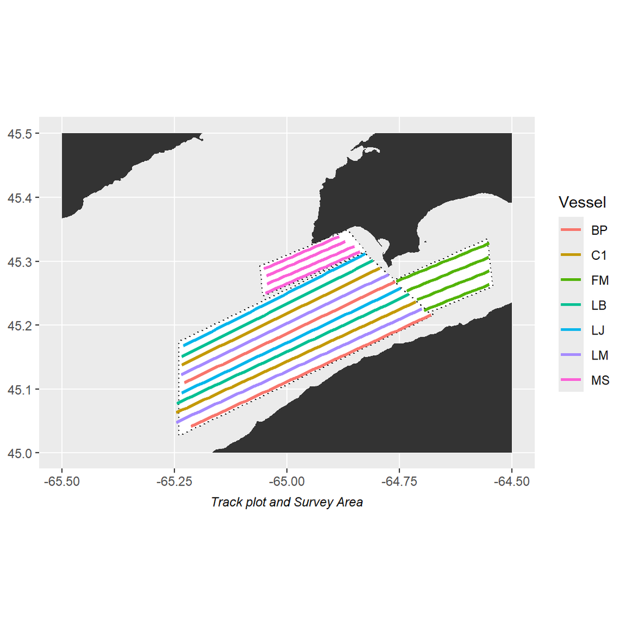

There was no plankton tow or CTD cast conducted.

No tags were applied during this survey.

Samples were obtained for target strength estimation.

### Tides Tables

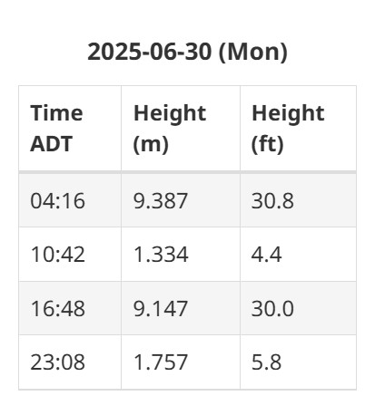

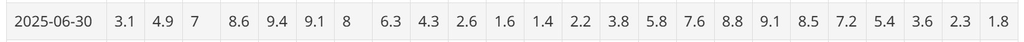

Tide Schedule for Margaretsville NS, Station #315m Source: www.waterlevels.gc.ca

### Acoustic Equipment

Each vessel was equipped with a Simrad ES38-18/200-18C combi (2-in-1) transducer prior to the survey that contains a 38kHz split beam and 200 kHz single beam transducer. Data was logged to the computer hard-drive for post-processing. All participating boats were calibrated on 38kHz before the survey.

## Survey Results

### Main Results

The results are subject to change as DFO will re-evaluate data editing, area estimation and apply a target strength.

**Preliminary biomass prediction for Scots Bay using standardized parallel transects is 15,790mt, and with turnover applied 11,509mt.**

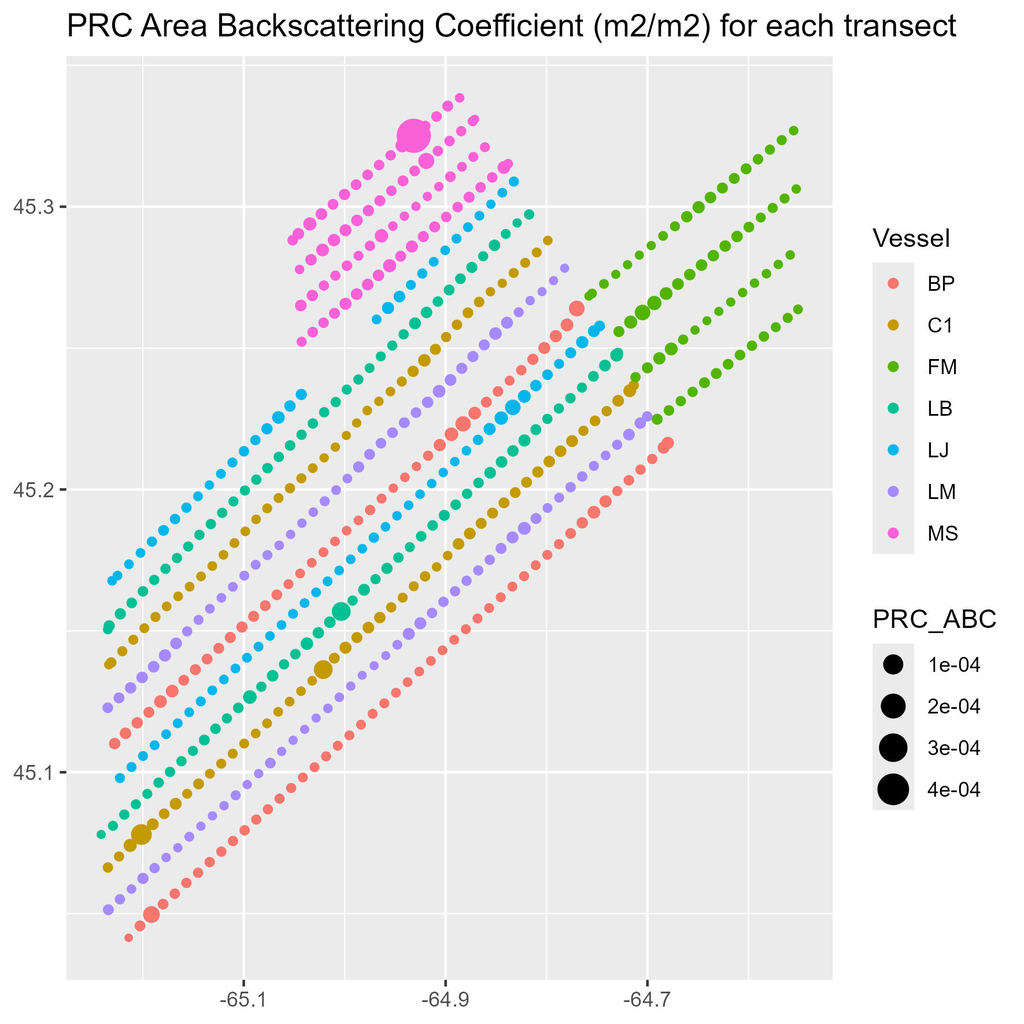

### Transect Details

Table 1: Transect Details

| Vessel | Transect # | Date/Time Start | Date/Time End | X | Y | Xend | Yend | Start Lat | Start Lon | End Lat | End Lon | Location | Distance (km) | Speed |
| --- | --- | --- | --- | --- | --- | --- | --- | --- | --- | --- | --- | --- | --- | --- |
| BP | T01 | 2025-06-30 19:38:24 | 2025-06-30 22:34:00 | -65.21399 | 45.04143 | -64.67983 | 45.21645 | NA | NA | NA | NA | SB | 46.38 | 8.56 |
| BP | T02 | 2025-06-30 23:04:17 | 2025-07-01 01:38:59 | -64.76032 | 45.26838 | -65.22792 | 45.11014 | NA | NA | NA | NA | SB | 40.85 | 8.56 |
| C1 | T01 | 2025-06-30 19:50:51 | 2025-06-30 22:50:54 | -65.24604 | 45.06303 | -64.71359 | 45.23685 | NA | NA | NA | NA | SB | 47.40 | 8.53 |
| C1 | T02 | 2025-06-30 23:17:55 | 2025-07-01 01:50:33 | -64.79415 | 45.28916 | -65.23361 | 45.13807 | NA | NA | NA | NA | SB | 39.59 | 8.40 |
| FM | T01 | 2025-06-30 20:57:32 | 2025-06-30 21:49:50 | -64.69637 | 45.22353 | -64.55084 | 45.26370 | NA | NA | NA | NA | SB | 12.38 | 7.67 |
| FM | T02 | 2025-06-30 21:57:38 | 2025-06-30 22:48:58 | -64.55084 | 45.28488 | -64.71185 | 45.23972 | NA | NA | NA | NA | SB | 13.66 | 8.62 |
| FM | T03 | 2025-06-30 22:57:34 | 2025-06-30 23:59:12 | -64.73409 | 45.25410 | -64.55257 | 45.30627 | NA | NA | NA | NA | SB | 15.48 | 8.14 |
| FM | T04 | 2025-07-01 00:07:22 | 2025-07-01 01:15:39 | -64.55054 | 45.32838 | -64.75803 | 45.26841 | NA | NA | NA | NA | SB | 17.67 | 8.38 |
| LB | T01 | 2025-06-30 19:37:32 | 2025-06-30 23:06:49 | -65.24457 | 45.07772 | -64.72917 | 45.24832 | NA | NA | NA | NA | SB | 45.41 | 7.03 |
| LB | T02 | 2025-06-30 23:47:00 | 2025-07-01 02:35:27 | -64.80948 | 45.30110 | -65.23467 | 45.15050 | NA | NA | NA | NA | SB | 37.95 | 7.30 |
| LJ | T01 | 2025-06-30 19:40:48 | 2025-06-30 22:38:59 | -65.23399 | 45.09396 | -64.74746 | 45.25778 | NA | NA | NA | NA | SB | 42.49 | 7.73 |
| LJ | T02 | 2025-06-30 23:12:04 | 2025-07-01 01:33:12 | -64.82569 | 45.31201 | -65.23042 | 45.16769 | NA | NA | NA | NA | SB | 36.10 | 8.29 |
| LM | T01 | 2025-06-30 19:25:48 | 2025-06-30 22:36:41 | -65.24571 | 45.04811 | -64.70023 | 45.22584 | NA | NA | NA | NA | SB | 47.60 | 8.08 |
| LM | T02 | 2025-06-30 23:04:14 | 2025-07-01 01:47:28 | -64.77469 | 45.27962 | -65.23475 | 45.12280 | NA | NA | NA | NA | SB | 40.57 | 8.05 |
| MS | T01 | 2025-06-30 19:41:52 | 2025-06-30 21:04:28 | -65.04883 | 45.25032 | -64.83808 | 45.31518 | NA | NA | NA | NA | SB | 18.92 | 7.42 |
| MS | T02 | 2025-06-30 21:11:14 | 2025-06-30 22:14:53 | -64.85049 | 45.32359 | -65.04426 | 45.26482 | NA | NA | NA | NA | SB | 16.97 | 8.64 |
| MS | T03 | 2025-06-30 22:20:49 | 2025-06-30 23:16:56 | -65.04611 | 45.27731 | -64.87112 | 45.33093 | NA | NA | NA | NA | SB | 15.31 | 8.84 |
| MS | T04 | 2025-06-30 23:23:11 | 2025-07-01 00:24:03 | -64.88405 | 45.33873 | -65.05150 | 45.28815 | NA | NA | NA | NA | SB | 14.71 | 7.83 |

### Survey Summary

Table 2: Acoustic Survey Results

| Vessel | Transect No. | Target Strength (db/kg) | Mean Sa (/m2) | Biomass Density (kg/m2) |
| --- | --- | --- | --- | --- |
| MS | T04 | -35.5 | -43.857 | 0.146 |
| FM | T03 | -35.5 | -50.132 | 0.034 |
| C1 | T01 | -35.5 | -50.877 | 0.029 |
| MS | T03 | -35.5 | -51.189 | 0.027 |
| BP | T02 | -35.5 | -51.892 | 0.023 |
| LB | T01 | -35.5 | -52.073 | 0.022 |
| MS | T01 | -35.5 | -52.169 | 0.022 |
| BP | T01 | -35.5 | -54.083 | 0.014 |
| LM | T02 | -35.5 | -54.226 | 0.013 |
| LJ | T01 | -35.5 | -54.476 | 0.013 |
| FM | T01 | -35.5 | -54.922 | 0.011 |
| MS | T02 | -35.5 | -55.008 | 0.011 |
| LB | T02 | -35.5 | -55.253 | 0.011 |
| FM | T04 | -35.5 | -55.439 | 0.010 |
| FM | T02 | -35.5 | -55.541 | 0.010 |
| LM | T01 | -35.5 | -55.782 | 0.009 |
| LJ | T02 | -35.5 | -55.810 | 0.009 |
| C1 | T02 | -35.5 | -57.187 | 0.007 |

Note:  
Transects are listed from greatest to least backscatter.

Table 3: Survey Summary Table

[output not shown]

### Greatest Biomass Densities

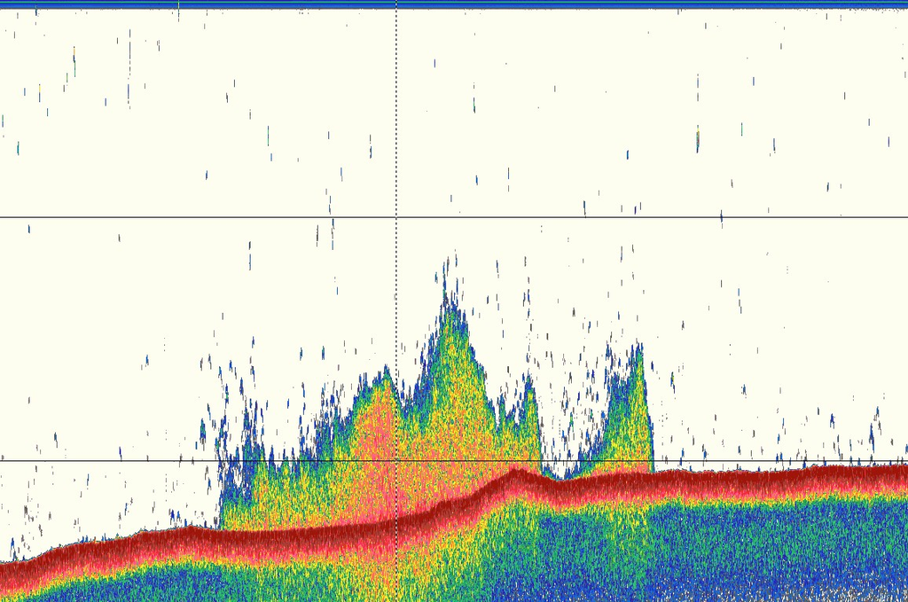

A snip from the transect with the greatest biomass density (kg/m2)

The single point with the largest biomass density (kg/m2) was recorded by **MS**, at the following location:

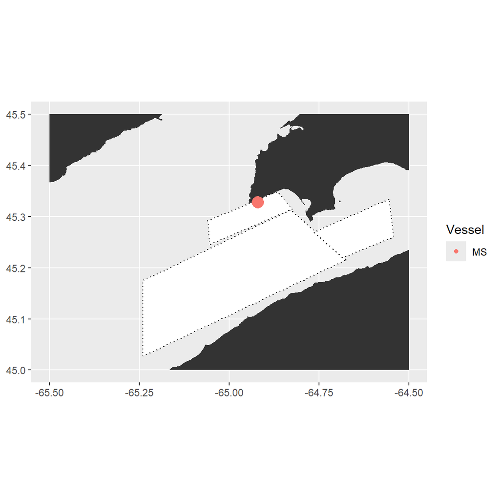

The transect with the greatest average biomass density (kg/m2) was recorded by **MS**, at the following location:

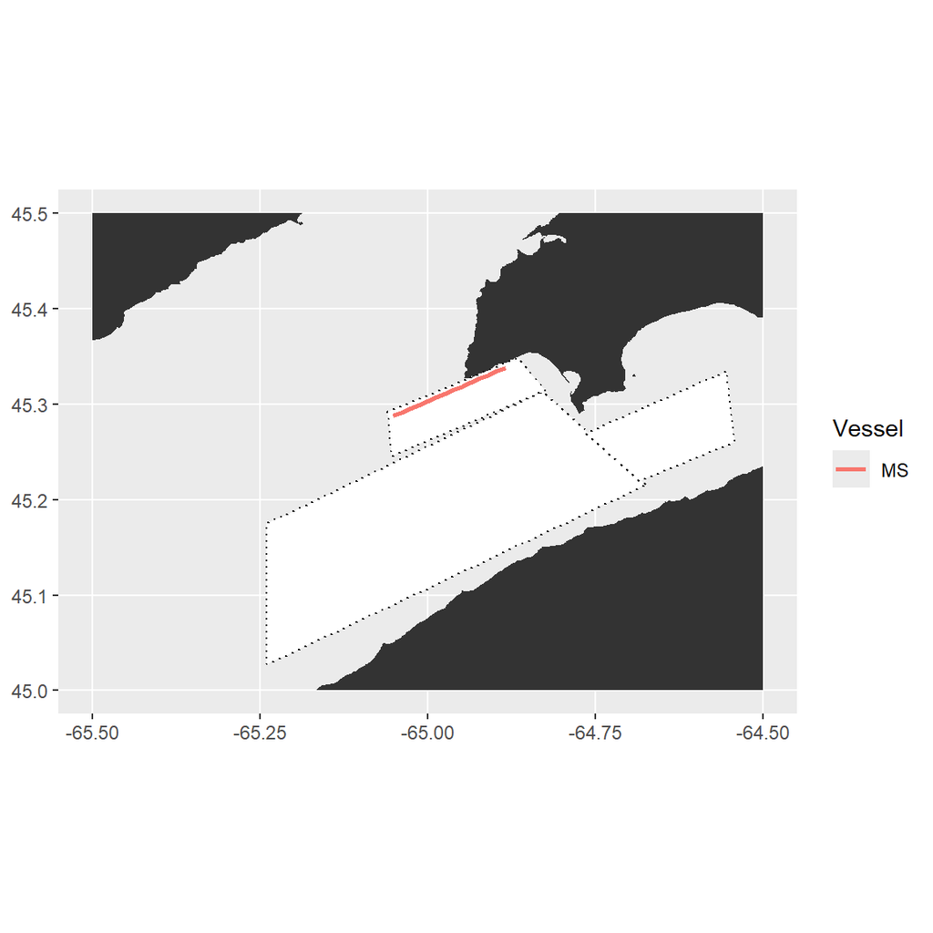

### Annual Summaries

This table does not include the biomass from adhoc surveys.

Table 4: Annual Comparison Table

| Ground | Survey Number | Current Year Survey Date | Current Year HSC Estimate | Current Year HSC Turnover Adjusted | Previous Year Survey Date | Previous Year HSC Estimate | Previous Year HSC Turnover Adjusted | Previous Year DFO Estimate | Previous Year DFO Turnover Adjusted |
| --- | --- | --- | --- | --- | --- | --- | --- | --- | --- |
| Scots Bay | 1 | 2025-05-06 | 12,306 | 12,306 | 2024-05-05 | 78,662 | 78,662 | 67,094 | 67,094 |
| Scots Bay | 2 | 2025-05-21 | 120,045 | 118,023 | 2024-05-20 | 29,842 | 17,255 | 28,750 | 20,566 |
| Scots Bay | 3 | 2025-06-03 | 123,037 | 109,821 | 2024-06-02 | 93,804 | 89,523 | 61,745 | 57,220 |
| Scots Bay | 4 | 2025-06-16 | 14,184 | 0 | 2024-06-16 | 33,347 | 22,278 | 32,605 | 23,965 |
| Scots Bay | 5 | 2025-06-30 | 15,789 | 11,509 | 2024-07-01 | 7,252 | 3,123 | 4,682 | 705 |
| Scots Bay | 6 | 2025-07-14 | 7,114 | 5,137 | 2024-07-15 | 4,539 | 3,560 | 4,816 | 4,183 |
| Scots Bay | 7 | NA | NA | NA | 2024-07-29 | 32,655 | 32,016 | 33,994 | 33,327 |
| Scots Bay | 8 | NA | NA | NA | 2024-08-11 | 15,213 | 10,296 | 13,079 | 7,959 |
| Scots Bay | 9 | NA | NA | NA | 2024-08-25 | 9,206 | 6,810 | 8,459 | 6,338 |
| Scots Bay | 10 | NA | NA | NA | 2024-09-08 | 13,418 | 12,121 | 8,621 | 7,432 |
| Scots Bay | 11 | NA | NA | NA | 2024-09-23 | 8,735 | 7,098 | 6,478 | 5,427 |

Table 5: Annual Summary Table

| Year | Ground | HSC Estimate | HSC Turnover Adjusted | DFO Estimate | DFO Turnover Adjusted |
| --- | --- | --- | --- | --- | --- |
| 2024 | Scots Bay | 326,673 | 282,742 | 270,323 | 234,216 |
| 2025 | Scots Bay | 292,475 | 256,796 | NA | NA |

## Tagging, Plankton, and CTD Data

### Summary map

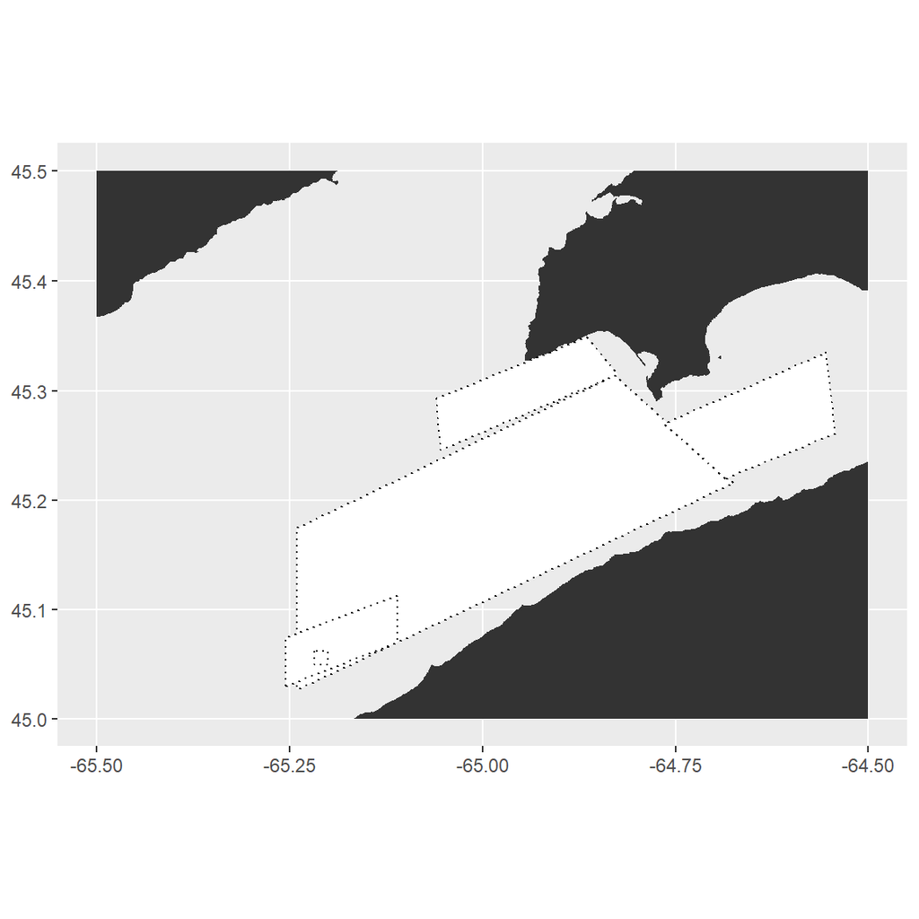

| Vessel | Tags |
| --- | --- |

### Plankton Data

#### Tow Summary Table

|  | Tow 1 | Tow 2 |
| --- | --- | --- |
| **Base Details** |  |  |
| Vessel | NA | NA |
| Set Number | NA | NA |
| Ground | SB | SB |
| Date | 30/06/2025 | 30/06/2025 |
| Wind Direction (km/h) | NA | NA |
| Swell (m) | NA | NA |
| Air Temp (c) | NA | NA |
| **Tow Details** |  |  |
| Tow Start | NA | NA |
| Tow End | NA | NA |
| Start Lat | NA | NA |
| End Lat | NA | NA |
| Start Lon | NA | NA |
| End Lon | NA | NA |
| Avg Tow Depth (m) | NA | NA |
| Speed | NA | NA |
| Heading | NA | NA |
| Tide Direction | NA | NA |
| **Other Data Collection** |  |  |
| Flow Start | NA | NA |
| Flow End | NA | NA |
| No. Revolutions | NA | NA |
| Distance (m) | NA | NA |
| Volume | NA | NA |
| Secchi Disappear (m) | NA | NA |
| Secchi Reappear (m) | NA | NA |

#### Tow Depth Profiles

[figure not shown]

Plankton tow depth profile #1

[figure not shown]

Plankton tow depth profile #2

### CTD Data

[figure not shown]

#### Sea surface temperatures

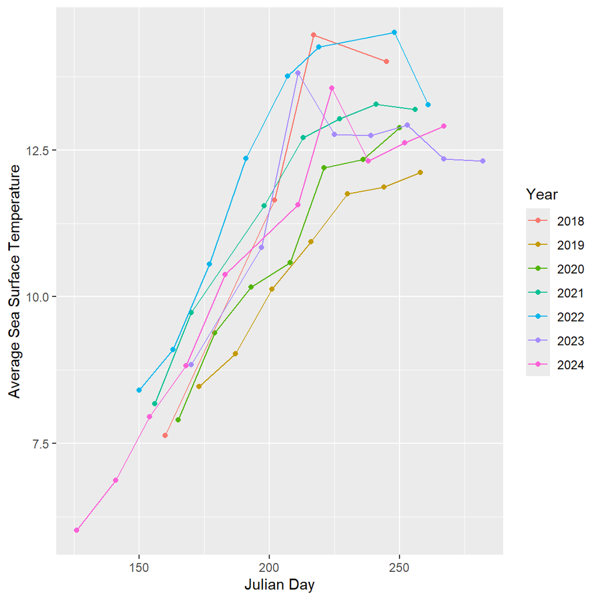

Annual average sea surface temperatures (SST) for Scots Bay.

## Vessel Performance

### Speed

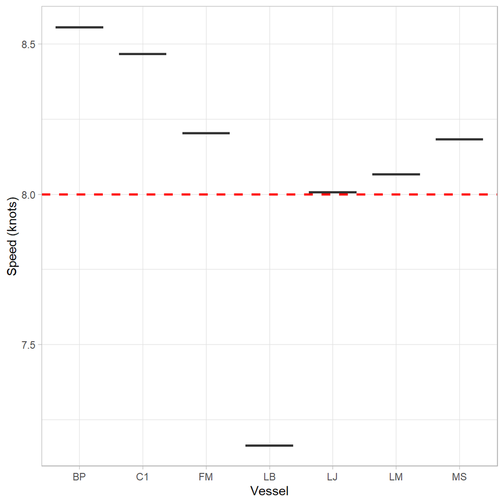

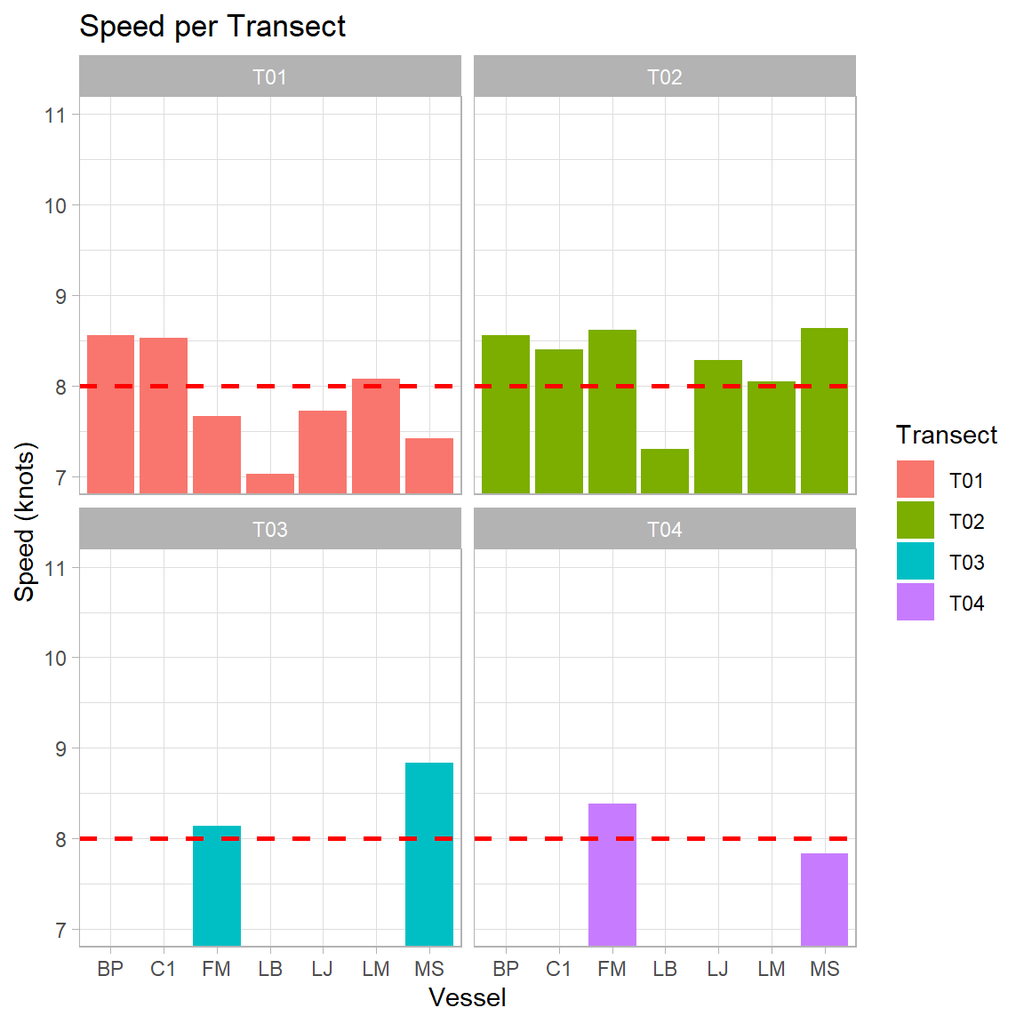

Average vessel speed was 8.09. This is above the 8 knot requirement; vessels are urged to slow down to prevent backscatter noise from interfering with the acoustic data.

The speed for each transect are rudimentary and are calculated based on distance. If a significant amount of distance is cut, the speed will appear slower.

### Distance

[figure not shown]

No significant distance was cut from the planned lines; vessels covered the planned area well.